# QK Box 6.7 & 6.11

Keough and Raimondi (1995) set up an experiment to examine the response of serpulid (polychaete worms) larvae to four types of biofilms on hard substrata in shallow marine waters. The four treatments were: sterile substrata, biofilms developed in the field with a net (to keep invertebrates), biofilms developed in the lab, and lab biofilms with a covering net (as a control for the presence of a net). The substrata were left for one week, and then the newly settled worms identified and counted. To control for small numbers of larvae passing through the netting during the conditioning period, they used an additional treatment, which was netted, and returned to the laboratory after one week and censused. The values of this treatment were used to adjust the numbers in the treatment that started in the field.

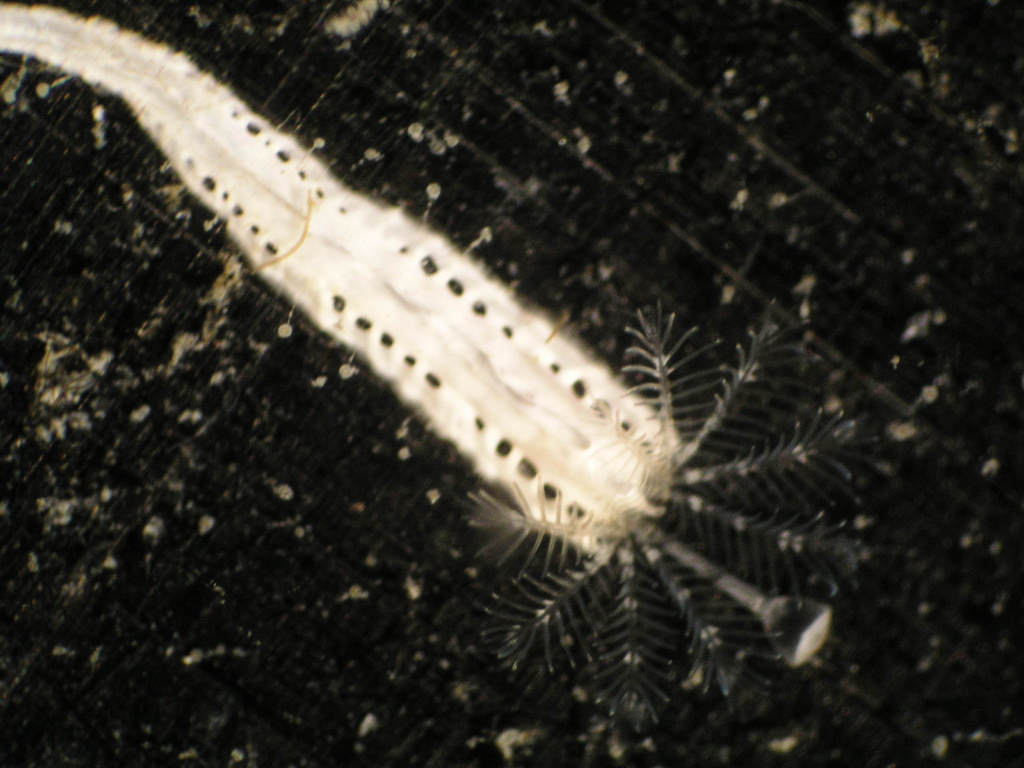

Serpulid polychaete worm. Photo M. Keough

The paper is here and the data file (also used in first edition) is here

Keough, M. J. & Raimondi, P. T. (1995). Responses of settling invertebrate larvae to bioorganic films: effects of different types of films. *Journal of Experimental Marine Biology and Ecology*, 185, 235-53.

### Preliminaries

First, load the required packages (pwr)

Import serpulid data file (serpulid.csv)

```r
serpulid <- read.csv("../data/serpulid.csv")
head(serpulid,10)
```

|  | film | serp | lserp | spir | bugula |
| --- | --- | --- | --- | --- | --- |
| 1 | SL | 94 | 1.973 | 0 | 4 |
| 2 | SL | 82 | 1.914 | 2 | 2 |
| 3 | SL | 74 | 1.869 | 2 | 8 |
| 4 | SL | 74 | 1.869 | 0 | 2 |
| 5 | SL | 122 | 2.086 | 2 | 14 |
| 6 | SL | 112 | 2.049 | 2 | 6 |
| 7 | SL | 60 | 1.778 | 0 | 12 |
| 8 | UL | 142 | 2.152 | 2 | 4 |
| 9 | UL | 80 | 1.903 | 0 | 6 |
| 10 | UL | 100 | 2.000 | 0 | 2 |

Make film a factor

```r
serpulid$film <- factor(serpulid$film)
```

### Fit model for log(serpulids)

```r
serpulid.aov <- aov(lserp~film, data=serpulid)
```

Check diagnostics

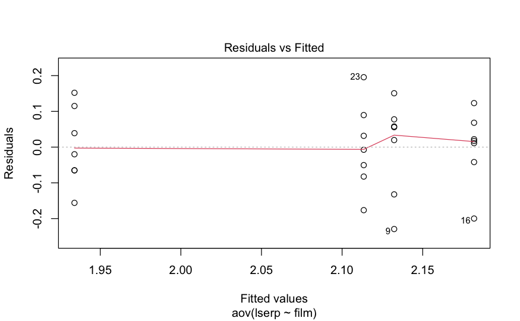

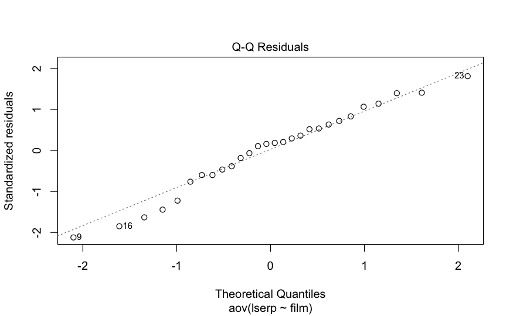

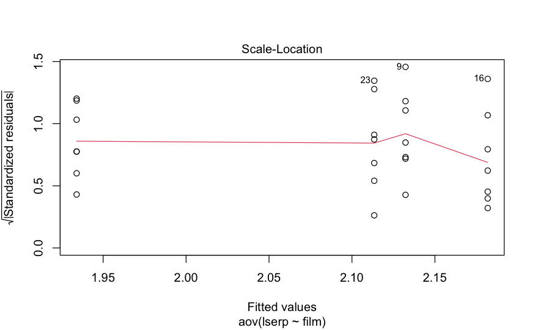

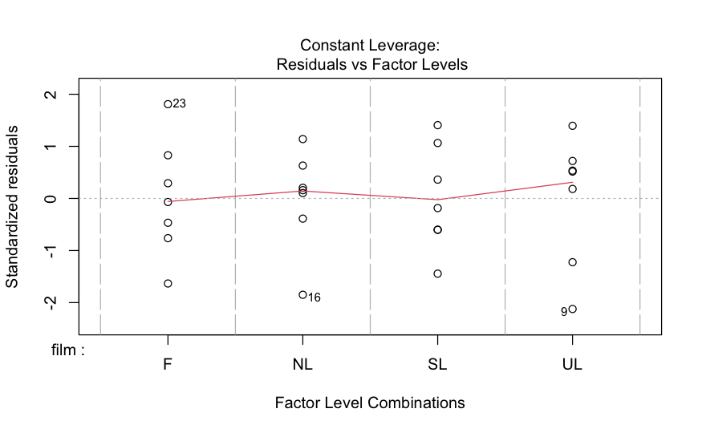

```r
plot(serpulid.aov)
```

Generate overall anova table

```r
summary(serpulid.aov)
```

```
            Df Sum Sq Mean Sq F value  Pr(>F)
film         3 0.2458 0.08192   6.015 0.00331 **
Residuals   24 0.3269 0.01362
---
Signif. codes:  0 ‘***’ 0.001 ‘**’ 0.01 ‘*’ 0.05 ‘.’ 0.1 ‘ ’ 1
```

For information, get treatment means

```r
aggregate(serpulid$lserp, list(serpulid$film), FUN=mean)
```

| Group.1 | x |
| --- | --- |
| F | 2.113429 |
| NL | 2.181857 |
| SL | 1.934000 |
| UL | 2.132286 |

## Generate planned comparisons

We’re doing this by defining contrasts and refitting the model using this contrast. The planned comparison then appears as the first effect when we look at the model fitting (i.e., film1).

### UL vs NL

```r
contrasts(serpulid$film) <- c(0,1,0,-1)
contrasts(serpulid$film)
```

```
   [,1]       [,2]       [,3]
F     0 -0.5000000 -0.7071068
NL    1 -0.1666667  0.4714045
SL    0  0.8333333 -0.2357023
UL   -1 -0.1666667  0.4714045
```

```r
# Refit the model with new contrasts

serpulid.aov <- aov(lserp~film, data=serpulid)
summary.lm(serpulid.aov)
```

```
Call:
aov(formula = lserp ~ film, data = serpulid)

Residuals:
     Min       1Q   Median       3Q      Max
-0.22929 -0.06500  0.01843  0.07054  0.19557

Coefficients:
            Estimate Std. Error t value Pr(>|t|)
(Intercept)  2.09039    0.02206  94.780  < 2e-16 ***
film1        0.02479    0.03119   0.795  0.43461
film2       -0.16407    0.04411  -3.720  0.00107 **
film3        0.08344    0.04411   1.892  0.07067 .
---
Signif. codes:  0 ‘***’ 0.001 ‘**’ 0.01 ‘*’ 0.05 ‘.’ 0.1 ‘ ’ 1

Residual standard error: 0.1167 on 24 degrees of freedom
Multiple R-squared:  0.4292,    Adjusted R-squared:  0.3578
F-statistic: 6.015 on 3 and 24 DF,  p-value: 0.003314
```

### F vs average (NL & UL)

```r
contrasts(serpulid$film) <- c(2,-1,0,-1)
contrasts(serpulid$film)
```

```
   [,1]       [,2]        [,3]
F     2 -0.2867757  0.03306064
NL   -1 -0.3677574 -0.66939360
SL    0  0.8603272 -0.09918192
UL   -1 -0.2057940  0.73551488
```

```r
# Refit the model with new contrasts

serpulid.aov <- aov(lserp~film, data=serpulid)
summary.lm(serpulid.aov)
```

```
Call:
aov(formula = lserp ~ film, data = serpulid)

Residuals:
     Min       1Q   Median       3Q      Max
-0.22929 -0.06500  0.01843  0.07054  0.19557

Coefficients:
            Estimate Std. Error t value Pr(>|t|)
(Intercept)  2.09039    0.02206  94.780  < 2e-16 ***
film1       -0.01455    0.01801  -0.808 0.427118
film2       -0.18341    0.04411  -4.158 0.000353 ***
film3       -0.01414    0.04411  -0.321 0.751322
---
Signif. codes:  0 ‘***’ 0.001 ‘**’ 0.01 ‘*’ 0.05 ‘.’ 0.1 ‘ ’ 1

Residual standard error: 0.1167 on 24 degrees of freedom
Multiple R-squared:  0.4292,    Adjusted R-squared:  0.3578
F-statistic: 6.015 on 3 and 24 DF,  p-value: 0.003314
```

### SL vs average (F & NL & UL)

```r
contrasts(serpulid$film) <- c(-1,-1,3,-1)
contrasts(serpulid$film)
```

```
   [,1]        [,2]       [,3]
F    -1 -0.67052910 -0.4658942
NL   -1  0.73874075 -0.3477481
SL    3  0.00000000  0.0000000
UL   -1 -0.06821164  0.8136423
```

```r
# Refit the model with new contrasts
serpulid.aov <- aov(lserp~film, data=serpulid)
summary.lm(serpulid.aov)
```

```
Call:
aov(formula = lserp ~ film, data = serpulid)

Residuals:
     Min       1Q   Median       3Q      Max
-0.22929 -0.06500  0.01843  0.07054  0.19557

Coefficients:
             Estimate Std. Error t value Pr(>|t|)
(Intercept)  2.090393   0.022055  94.780  < 2e-16 ***
film1       -0.052131   0.012734  -4.094 0.000415 ***
film2        0.049265   0.044111   1.117 0.275117
film3       -0.008453   0.044111  -0.192 0.849643
---
Signif. codes:  0 ‘***’ 0.001 ‘**’ 0.01 ‘*’ 0.05 ‘.’ 0.1 ‘ ’ 1

Residual standard error: 0.1167 on 24 degrees of freedom
Multiple R-squared:  0.4292,    Adjusted R-squared:  0.3578
F-statistic: 6.015 on 3 and 24 DF,  p-value: 0.003314
```

## Diagnostics for untransformed data

We used log-transformed data to match the original paper, but if analysing these data from first principles, we’d look at the raw data first to decide which form of model or transformation to use.

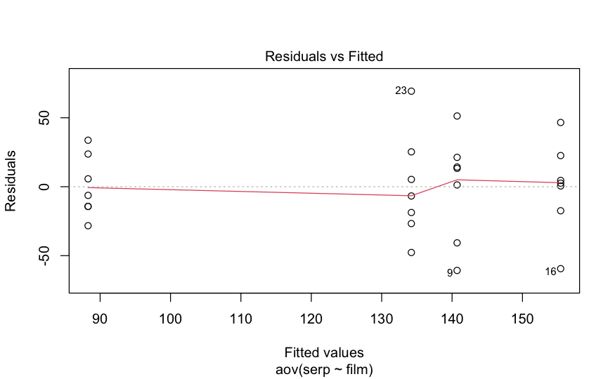

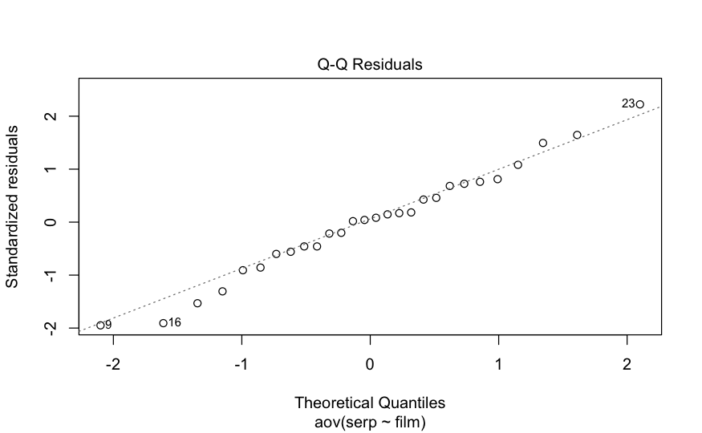

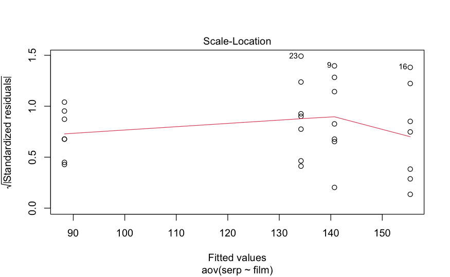

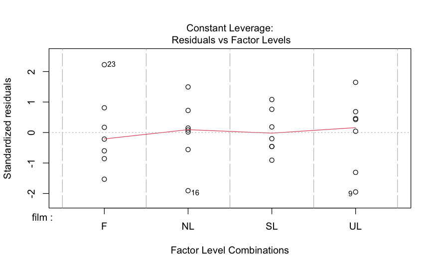

```r
serpraw.aov <- aov(serp~film, data=serpulid)
plot(serpraw.aov)
```

## Information for power analysis using spirorbids, *Bugula*

These calculations are used for Box 6.11, where we consider data for two other invertebrate groups, spirorbid polychaetes and bryozoans in the genus *Bugula*, mainly *B. neritina.*

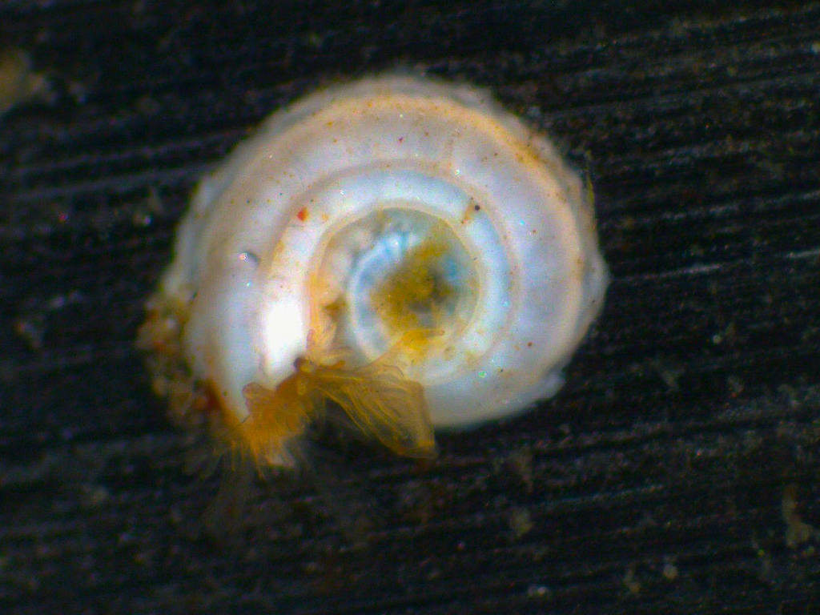

Spirorbid polychaete worm, c. 2mm diameter. Mick Keough

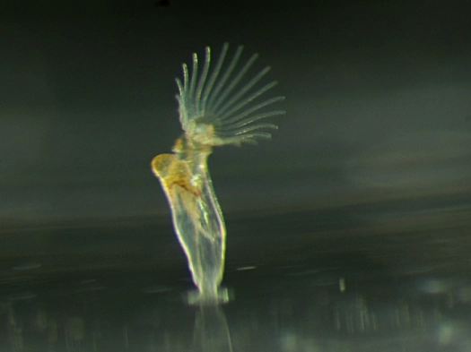

Recently metamorphosed bryozoan, *Bugula*. Approximately 1.5 mm high. Mick Keough

### Required information

We need to run the analysis on each of these groups, to get two important pieces of information. We need estimates of the variance, and we generally use the residual mean square. We also want an estimate of a baseline for calculating a hypothetical Effect Size. In the context of this question, we’ll use the means for unfilmed surfaces, as we are thinking about the potential for our treatments to increase recruitment.

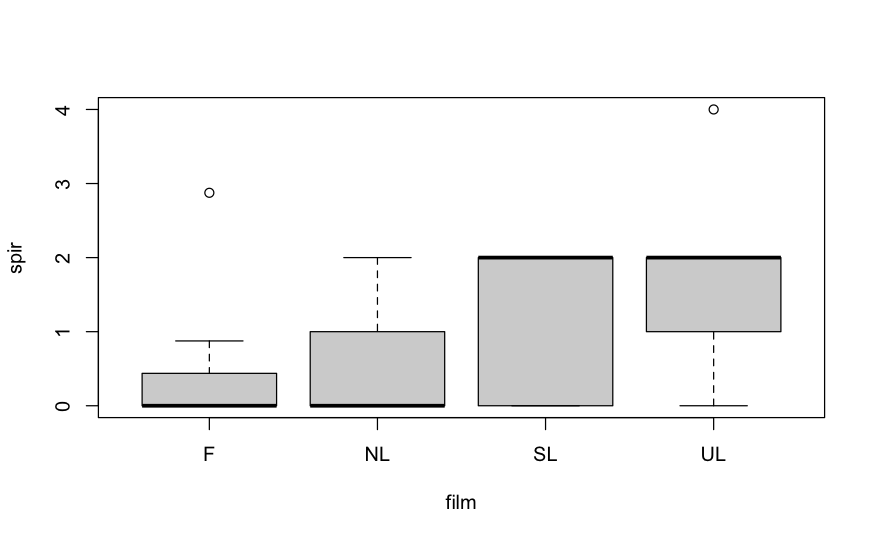

```r
boxplot(spir~film, data=serpulid)
```

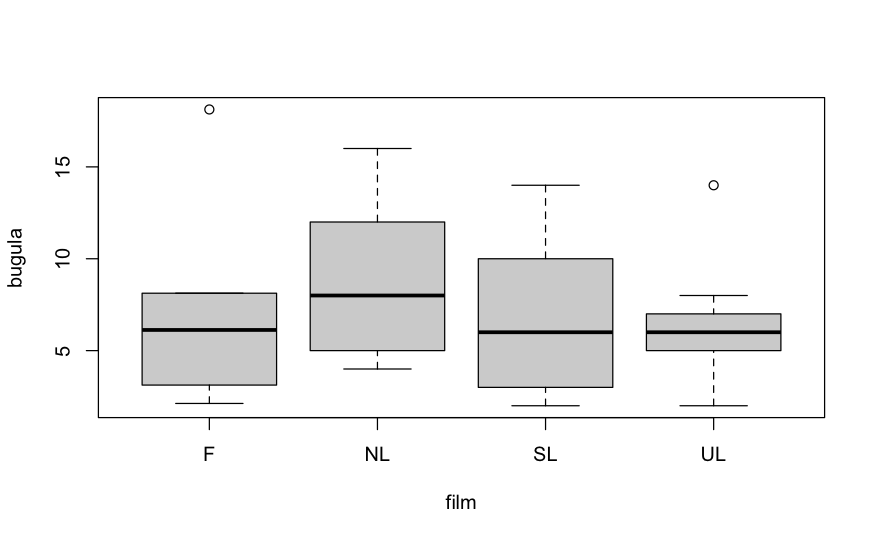

```r
boxplot(bugula~film, data=serpulid)
```

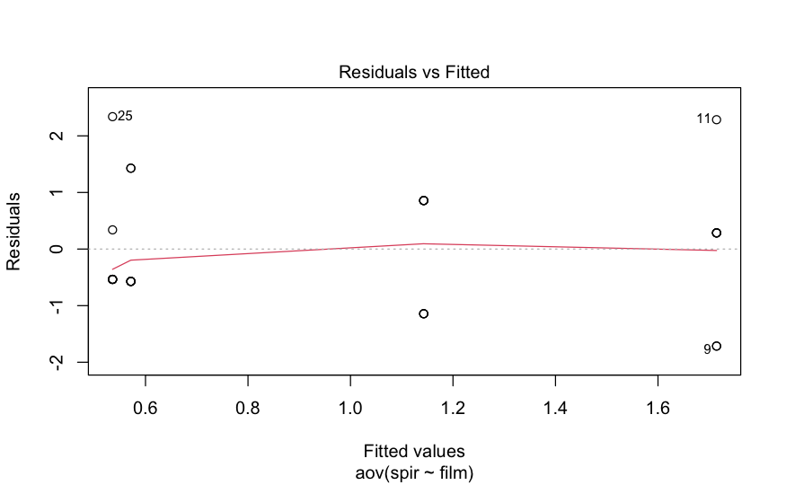

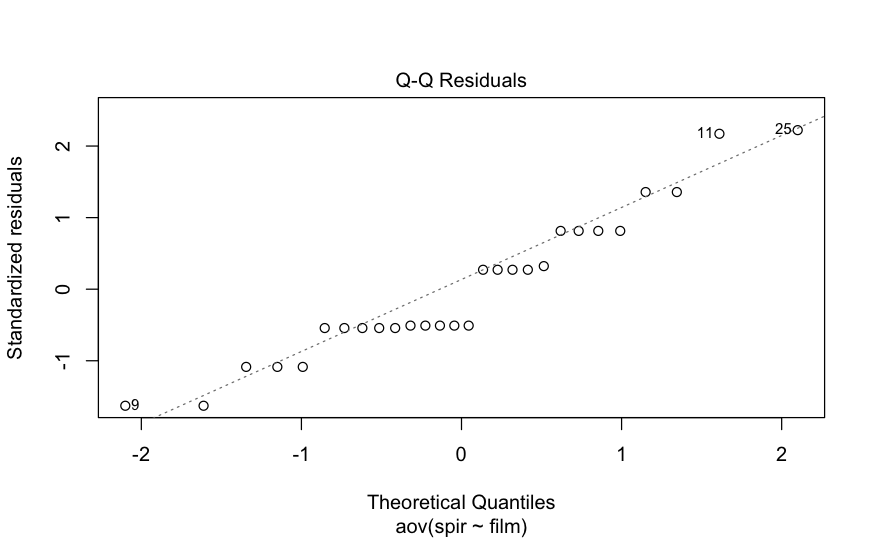

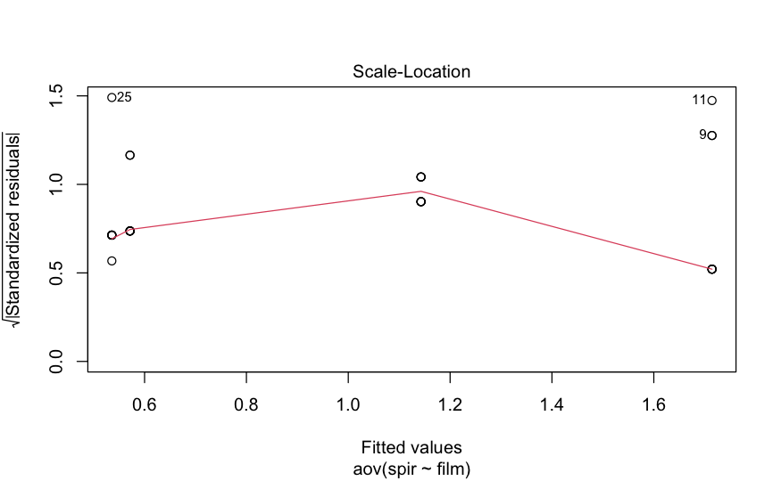

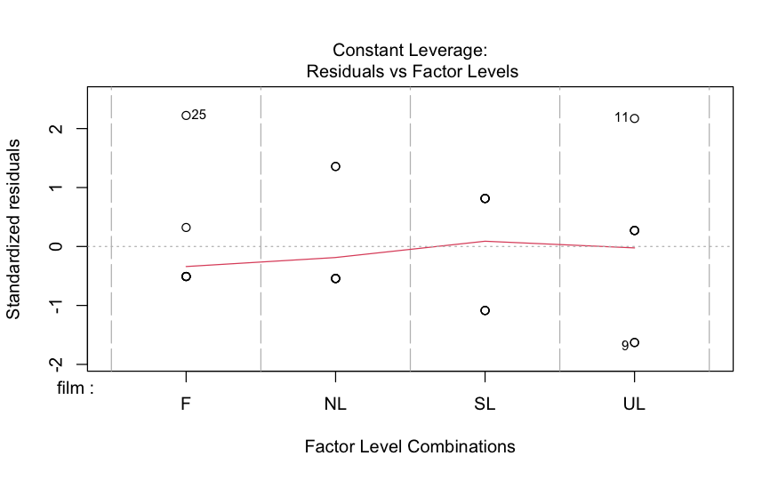

```r
spir.aov<-aov(spir~film, data=serpulid)
plot(spir.aov)
```

```r
summary(spir.aov)
```

```
            Df Sum Sq Mean Sq F value Pr(>F)
film         3  6.507   2.169   1.678  0.198
Residuals   24 31.022   1.293
```

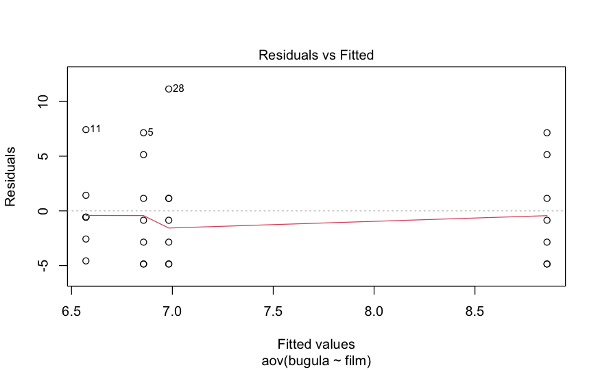

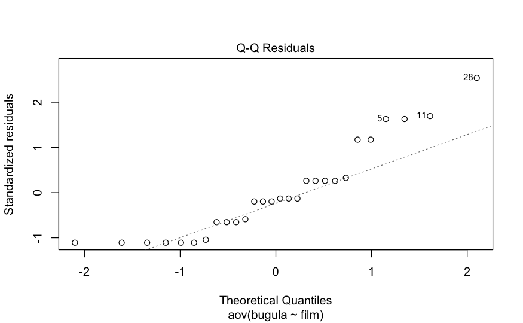

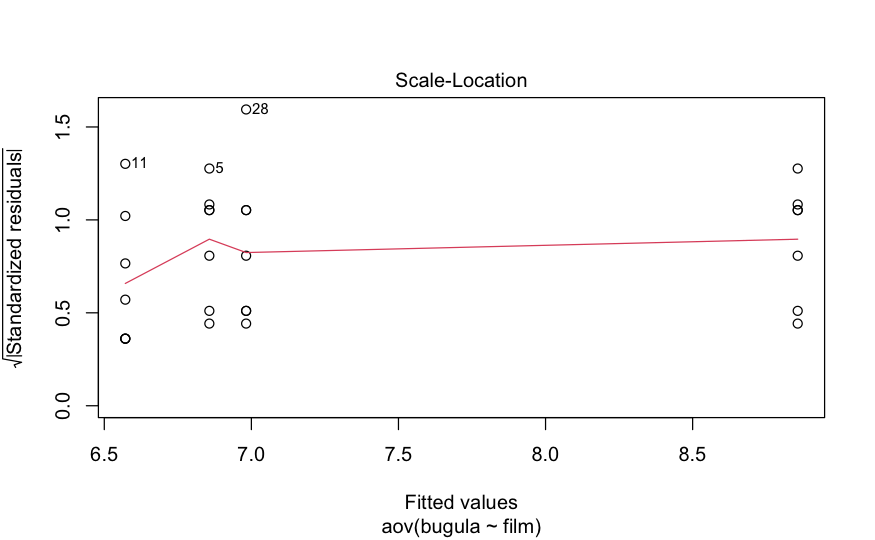

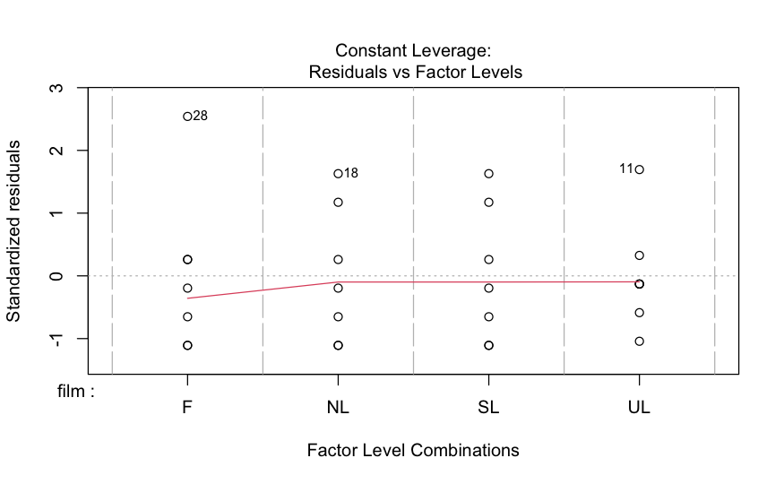

```r
bugula.aov<-aov(bugula~film, data=serpulid)
plot(bugula.aov)
```

```r
summary(bugula.aov)
```

```
            Df Sum Sq Mean Sq F value Pr(>F)
film         3   22.8   7.587   0.338  0.798
Residuals   24  538.3  22.429
```

```r
spirmean<-summarySE(data=serpulid,measurevar = "spir", groupvars = "film")
spirmean
```

| film | N | spir | sd | se | ci |
| --- | --- | --- | --- | --- | --- |
| F | 7 | 0.5357143 | 1.0818442 | 0.4088987 | 1.0005390 |
| NL | 7 | 0.5714286 | 0.9759001 | 0.3688556 | 0.9025570 |
| SL | 7 | 1.1428571 | 1.0690450 | 0.4040610 | 0.9887017 |
| UL | 7 | 1.7142857 | 1.3801311 | 0.5216405 | 1.2764084 |

```r
bugmean<-summarySE(data=serpulid,measurevar = "bugula", groupvars = "film")
bugmean
```

| film | N | bugula | sd | se | ci |
| --- | --- | --- | --- | --- | --- |
| F | 7 | 6.982143 | 5.520524 | 2.086562 | 5.105634 |
| NL | 7 | 8.857143 | 4.740906 | 1.791894 | 4.384607 |
| SL | 7 | 6.857143 | 4.740906 | 1.791894 | 4.384607 |
| UL | 7 | 6.571429 | 3.779645 | 1.428571 | 3.495588 |

### Power calculations

There are two scenarios in Box 6.11. Both involve a doubling of settlement from the base treatment SL above. In the first scenario, one treatment is 6.86 and the others are 13.72. In the second scenario, treatment means are spaced evenly between 6.86 and 13.72.

```r
alphasq1<-3*var(c(6.86, 13.72, 13.72,13.72))
alphasq2<-3*var(c(6.86, 9.14, 11.44,13.72))
msres=22.43
n=7
p=4
lambda1<-n*alphasq1/msres
lambda1
```

```
[1] 11.01484
```

```r
lambda2<-n*alphasq2/msres
lambda2
```

```
[1] 8.168685
```

```r
f1<-sqrt(alphasq1/p/msres)
f1
```

```
[1] 0.6272059
```

```r
f2<-sqrt(alphasq2/p/msres)
f2
```

```
[1] 0.5401285
```

```r
#For scenario 1, λ= 11.01 and Cohens *f* = 0.627
#For scenario 2, λ= 8.16 and Cohens *f* = 0.54
# scenario 1: power
pwr.anova.test(k=p,f=f1,sig.level=0.05, n=n)
```

```
     Balanced one-way analysis of variance power calculation

              k = 4
              n = 7
              f = 0.6272059
      sig.level = 0.05
          power = 0.7298327

NOTE: n is number in each group
```

```r
#scenario 2: power
pwr.anova.test(k=p,f=f2,sig.level=0.05, n=n)
```

```
     Balanced one-way analysis of variance power calculation

              k = 4
              n = 7
              f = 0.5401285
      sig.level = 0.05
          power = 0.5860053

NOTE: n is number in each group
```

```r
#scenario 1: required sample size
pwr.anova.test(k=p,f=f1,sig.level=0.05, power=0.8)
```

```
     Balanced one-way analysis of variance power calculation

              k = 4
              n = 7.976459
              f = 0.6272059
      sig.level = 0.05
          power = 0.8

NOTE: n is number in each group
```

```r
#scenario 2: required sample size
pwr.anova.test(k=p,f=f2,sig.level=0.05, power=0.8)
```

```
     Balanced one-way analysis of variance power calculation

              k = 4
              n = 10.37355
              f = 0.5401285
      sig.level = 0.05
          power = 0.8

NOTE: n is number in each group
```